# 5,6일차

## Business Understanding

- 공유자전거 서비스 업계의 도메인을 이해
- 자전거라는 상품 대여
- 대여되지 않은 자전거 대수가 적을수록 사업이 잘 된다고 판단
- 수요량을 잘 이해하고 있다면 인력이나 자원 할당의 최적화가 가능
- 요일, 날짜, 시간, 날씨에 따라 고객들의 서비스 이용량 증감 파악

## Data Understading

- 2011 ~ 2012년도까지 2년치
- 날짜정보, 기상정보, 이용정보
- 가용 데이터로 설정한 분석 방향성 및 목표 달성이 가능한지 여부 파악

#### Data Exploration

```python
import pandas as pd

df = pd.read_csv('test1_modify.csv')
print(df.shape)
df.head().T
```

```
(10886, 16)
```

|  | 0 | 1 | 2 | 3 | 4 |
| --- | --- | --- | --- | --- | --- |
| season | 1.000 | 1.000 | 1.000 | 1.000 | 1.000 |
| holiday | 0.000 | 0.000 | 0.000 | 0.000 | 0.000 |
| workingday | 0.000 | 0.000 | 0.000 | 0.000 | 0.000 |
| weather | 1.000 | 1.000 | 1.000 | 1.000 | 1.000 |
| temp | 9.840 | 9.020 | 9.020 | 9.840 | 9.840 |
| atemp | 14.395 | 13.635 | 13.635 | 14.395 | 14.395 |
| humidity | 81.000 | 80.000 | 80.000 | 75.000 | 75.000 |
| windspeed | 0.000 | 0.000 | 0.000 | 0.000 | 0.000 |
| casual | 3.000 | 8.000 | 5.000 | 3.000 | 0.000 |
| registered | 13.000 | 32.000 | 27.000 | 10.000 | 1.000 |
| count | 16.000 | 40.000 | 32.000 | 13.000 | 1.000 |
| year | 2011.000 | 2011.000 | 2011.000 | 2011.000 | 2011.000 |
| month | 1.000 | 1.000 | 1.000 | 1.000 | 1.000 |
| day | 1.000 | 1.000 | 1.000 | 1.000 | 1.000 |
| hour | 0.000 | 1.000 | 2.000 | 3.000 | 4.000 |
| dayofweek | 5.000 | 5.000 | 5.000 | 5.000 | 5.000 |

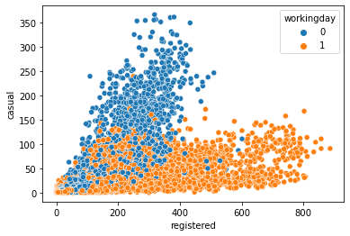

```python
import seaborn as sns

sns.scatterplot(data=df, x='registered', y='casual', hue='workingday')
```

```python
df.columns
```

```
Index(['season', 'holiday', 'workingday', 'weather', 'temp', 'atemp',
       'humidity', 'windspeed', 'casual', 'registered', 'count', 'year',
       'month', 'day', 'hour', 'dayofweek'],
      dtype='object')
```

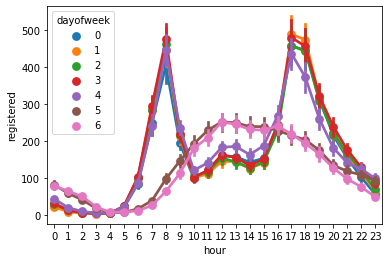

```python
sns.pointplot(data=df, x='hour', y='registered', hue='dayofweek')
```

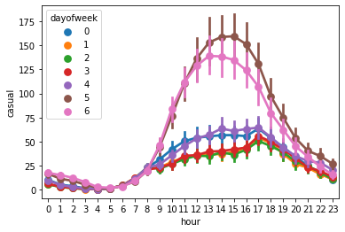

```python
sns.pointplot(data=df, x='hour', y='casual', hue='dayofweek')

# 등록 회원은 출퇴근 시간대에 사용량이 빈번하고,
# 비등록 회원은 점심 시간대에 사용량이 빈번하다.
```

## Data Preparation

- train, test split -> row 분리
- 문제(feature)와 정답(label) 분리 -> column 분리
- 날짜, 날씨, 시간과 같은 정보가 casual, registered, count에 영향을 줄 것

```python
df.columns
```

```
Index(['season', 'holiday', 'workingday', 'weather', 'temp', 'atemp',
       'humidity', 'windspeed', 'casual', 'registered', 'count', 'year',
       'month', 'day', 'hour', 'dayofweek'],
      dtype='object')
```

```python
# feature, label split
features = ['season', 'holiday', 'workingday', 'weather', 'temp', 'atemp',
       'humidity', 'windspeed', 'year', 'month', 'day', 'hour', 'dayofweek']
label = 'count'
```

```python
# train, test split
train, test = df[0::2], df[1::2]
train, test = train.reset_index(), test.reset_index()
```

```python
X_train, y_train = train[features], train[label]
X_test, y_test = test[features], test[label]
```

## Modeling

- 지도학습의 사례 2가지(객관식, 주관식)
- Classification(분류): 객관식(경우의 수)
- Regression(회귀): 주관식(숫자)
- 현 데이터셋은 숫자를 공부하는 것이므로 회귀문제
- 예외: Logistic Regression

```python
# scikit-learn
from sklearn.ensemble import RandomForestRegressor as rf

# 알고리즘 생성
model = rf()

# fitting, 문제집을 가지고 학습하는 개념
model.fit(X_train, y_train)
```

```
RandomForestRegressor()
```

```python
# 시험보고 점수 확인
train_score = model.score(X_train, y_train)
test_score = model.score(X_test, y_test)
print(train_score, test_score)
```

```
0.9921316708708235 0.9264614872591003
```

## 결정계수(R-squared, R2)

- 회귀 분석이 얼마나 잘 되었는지 평가하는 지표
- 샘플의 타깃과 예측한 값의 차이를 제곱하여 더함
- 타깃과 타깃 평균의 차이를 제곱하여 더한 값으로 나눔
- 타깃의 평균 정도를 예측하는 수준이라면(분자와 분모가 비슷하다면) R2는 0에 가까워지고,
- 예측이 타깃에 가까워지면(분자가 0에 가까워지기 때문에) 1에 가까운 값이 됨

#### 다양한 회귀문제 평가지표들

- R(Root), M(Mean), S(Squared), L(Log), P(Percentile), A(Absolute), E(Error)
- MSE: 오차를 제곱하여 평균
- MAE: 오차를 절대값 씌우고 평균
- MAPE: 오차의 비율을 절대값 씌우고 평균
- RMSE: 오차를 제곱하여 평균한 것에 제곱근 적용
- RMSLE: 로그오차를 제곱하여 평균한 것에 제곱근 적용

```python
# 로그오차: 작은 값들끼리의 차이와 큰 값들끼리의 차이에 차등을 두기 위함
# 정답: 1, 예측: 2 --> 오차: 1
# 정답: 1001, 예측: 1002 --> 오차: 1

import numpy as np

err1 = np.log(2) - np.log(1)
err2 = np.log(1002) - np.log(1001)
print(err1, err2)
```

```
0.6931471805599453 0.0009985023295895346
```

## 과대적합과 과소적합

- overfitting: 샘플에 모델이 과하게 적합되어 있는 상태
- underfitting: 샘플에 모델이 너무 부족하게 접합되어 있는 상태

```python
from sklearn.tree import DecisionTreeRegressor as dt

model_dt = dt()
model_dt.fit(X_train, y_train)

train_score = model_dt.score(X_train, y_train)
test_score = model_dt.score(X_test, y_test)

print(train_score, test_score)
```

```
1.0 0.8621013888382127
```

```python
# 데이터의 정답을 예측
model.predict(X_train)
```

```
array([ 21.21,  29.76,   3.15, ..., 561.49, 247.76, 130.29])
```

```python
for_plot = pd.DataFrame()

for_plot['train_predict'] = model.predict(X_train)
for_plot['train_actual'] = y_train
for_plot['test_predict'] = model.predict(X_test)
for_plot['test_actual'] = y_test
for_plot.head()
```

|  | train_predict | train_actual | test_predict | test_actual |
| --- | --- | --- | --- | --- |
| 0 | 21.21 | 16 | 22.57 | 40 |
| 1 | 29.76 | 32 | 17.58 | 13 |
| 2 | 3.15 | 1 | 4.25 | 1 |
| 3 | 2.62 | 2 | 29.13 | 3 |
| 4 | 24.26 | 8 | 46.69 | 14 |

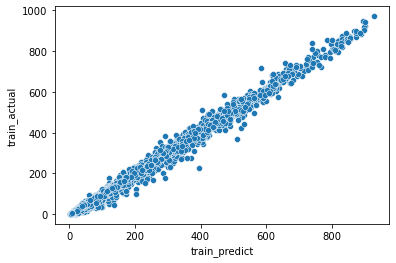

```python
import seaborn as sns

sns.scatterplot(data=for_plot, x='train_predict', y='train_actual')
# 학습용 문제로 학습했을 때, R2 값이 1에 아주 가까운 상황
```

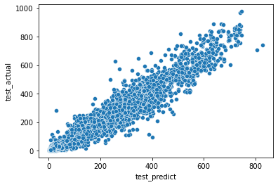

```python
sns.scatterplot(data=for_plot, x='test_predict', y='test_actual')
```

#### 일반화에 실패한 평가지표의 시각화

```python
for_plot_dt = pd.DataFrame()

for_plot_dt['train_predict'] = model_dt.predict(X_train)
for_plot_dt['train_actual'] = y_train
for_plot_dt['test_predict'] = model_dt.predict(X_test)
for_plot_dt['test_actual'] = y_test
for_plot_dt.head()
```

|  | train_predict | train_actual | test_predict | test_actual |
| --- | --- | --- | --- | --- |
| 0 | 16.0 | 16 | 16.0 | 40 |
| 1 | 32.0 | 32 | 2.0 | 13 |
| 2 | 1.0 | 1 | 2.0 | 1 |
| 3 | 2.0 | 2 | 8.0 | 3 |
| 4 | 8.0 | 8 | 75.0 | 14 |

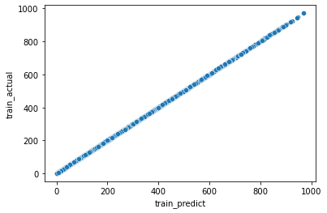

```python
sns.scatterplot(data=for_plot_dt, x='train_predict', y='train_actual')

# 학습용 문제로 학습했을 때 R2가 1인 상황
```

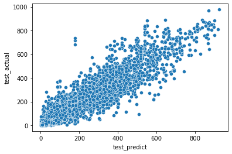

```python
sns.scatterplot(data=for_plot_dt, x='test_predict', y='test_actual')
```

## Feature selection

- 과적합을 방지하고, 일반화를 달성
- 모든 변수를 사용하지 않고 일부만 골라서 사용
- 학습속도 증진을 기대할 수 있음
- 방법론 3가지: filter, wrapper, embed

#### filter

- 기초통계량을 기반으로 feature 간의 높은 상관계수를 가지는 feature를 사용하는 방법
- 센서류의 경우 종종 발생
- filter 방식이 유효한 경우는 분야에 따라 다름

```python
df.describe().T.sort_values(by='std')
```

|  | count | mean | std | min | 25% | 50% | 75% | max |
| --- | --- | --- | --- | --- | --- | --- | --- | --- |
| holiday | 10886.0 | 0.028569 | 0.166599 | 0.00 | 0.0000 | 0.000 | 0.0000 | 1.0000 |
| workingday | 10886.0 | 0.680875 | 0.466159 | 0.00 | 0.0000 | 1.000 | 1.0000 | 1.0000 |
| year | 10886.0 | 2011.501929 | 0.500019 | 2011.00 | 2011.0000 | 2012.000 | 2012.0000 | 2012.0000 |
| weather | 10886.0 | 1.418427 | 0.633839 | 1.00 | 1.0000 | 1.000 | 2.0000 | 4.0000 |
| season | 10886.0 | 2.506614 | 1.116174 | 1.00 | 2.0000 | 3.000 | 4.0000 | 4.0000 |
| dayofweek | 10886.0 | 3.013963 | 2.004585 | 0.00 | 1.0000 | 3.000 | 5.0000 | 6.0000 |
| month | 10886.0 | 6.521495 | 3.444373 | 1.00 | 4.0000 | 7.000 | 10.0000 | 12.0000 |
| day | 10886.0 | 9.992559 | 5.476608 | 1.00 | 5.0000 | 10.000 | 15.0000 | 19.0000 |
| hour | 10886.0 | 11.541613 | 6.915838 | 0.00 | 6.0000 | 12.000 | 18.0000 | 23.0000 |
| temp | 10886.0 | 20.230860 | 7.791590 | 0.82 | 13.9400 | 20.500 | 26.2400 | 41.0000 |
| windspeed | 10886.0 | 12.799395 | 8.164537 | 0.00 | 7.0015 | 12.998 | 16.9979 | 56.9969 |
| atemp | 10886.0 | 23.655084 | 8.474601 | 0.76 | 16.6650 | 24.240 | 31.0600 | 45.4550 |
| humidity | 10886.0 | 61.886460 | 19.245033 | 0.00 | 47.0000 | 62.000 | 77.0000 | 100.0000 |
| casual | 10886.0 | 36.021955 | 49.960477 | 0.00 | 4.0000 | 17.000 | 49.0000 | 367.0000 |
| registered | 10886.0 | 155.552177 | 151.039033 | 0.00 | 36.0000 | 118.000 | 222.0000 | 886.0000 |
| count | 10886.0 | 191.574132 | 181.144454 | 1.00 | 42.0000 | 145.000 | 284.0000 | 977.0000 |

#### wrapper

- feature의 조합별로 평가지표 점수를 확인하여 점수가 가장 좋은 조합을 찾는 것
- forward selection, backward elimination, stepwise selection

```python
df.columns
```

```
Index(['season', 'holiday', 'workingday', 'weather', 'temp', 'atemp',
       'humidity', 'windspeed', 'casual', 'registered', 'count', 'year',
       'month', 'day', 'hour', 'dayofweek'],
      dtype='object')
```

```python
features = ['season', 'holiday', 'workingday', 'weather', 'temp', 'atemp',
       'humidity', 'windspeed', 'year', 'month', 'day', 'hour', 'dayofweek']
label = 'count'

train, test = df[0::2], df[1::2]
train, test = train.reset_index(), test.reset_index()

X_train, y_train = train[features], train[label]
X_test, y_test = test[features], test[label]

model = rf()
model.fit(X_train, y_train)
model.score(X_test, y_test)
```

```
0.9237748451120619
```

```python
features = ['season', 'workingday', 'weather', 'temp', 'atemp',
       'humidity', 'windspeed', 'year', 'month', 'day', 'hour', 'dayofweek']
label = 'count'

train, test = df[0::2], df[1::2]
train, test = train.reset_index(), test.reset_index()

X_train, y_train = train[features], train[label]
X_test, y_test = test[features], test[label]

model = rf()
model.fit(X_train, y_train)
model.score(X_test, y_test)
```

```
0.924834965385639
```

```python
from sklearn.feature_selection import RFE

features = ['season', 'holiday', 'workingday', 'weather', 'temp', 'atemp',
       'humidity', 'windspeed', 'year', 'month', 'day', 'hour', 'dayofweek']
label = 'count'

train, test = df[0::2], df[1::2]
train, test = train.reset_index(), test.reset_index()

X_train, y_train = train[features], train[label]
X_test, y_test = test[features], test[label]

model = rf()
model.fit(X_train, y_train)

selector = RFE(model)
selector.fit(X_train, y_train)
```

```
RFE(estimator=RandomForestRegressor())
```

```python
rfe_df = pd.DataFrame()
rfe_df['rank'] = selector.ranking_
rfe_df['feature'] = features
rfe_df.sort_values(by='rank')
```

|  | rank | feature |
| --- | --- | --- |
| 4 | 1 | temp |
| 5 | 1 | atemp |
| 8 | 1 | year |
| 9 | 1 | month |
| 11 | 1 | hour |
| 12 | 1 | dayofweek |
| 2 | 2 | workingday |
| 6 | 3 | humidity |
| 3 | 4 | weather |
| 10 | 5 | day |
| 0 | 6 | season |
| 7 | 7 | windspeed |
| 1 | 8 | holiday |

#### embed

- Tree 계열이나 Regularizer가 내부에 있는 경우
- 알고리즘에서 각 feature들이 의사결정에 사용된 정도를 이용
- 알고리즘의 공식문서에 Lasso, L1이 표현이 있는 경우

```python
model

# model 변수엔 학습이 끝난 RandomForest가 있고, Tree 계열의 알고리즘임
# 내부에 변수의 중요도가 내포되어 있음 -> feature별 중요도 파악 가능
```

```
RandomForestRegressor()
```

```python
model.feature_importances_
```

```
array([0.00804886, 0.00186461, 0.05293443, 0.01561171, 0.05098562,
       0.05772069, 0.02587044, 0.00853141, 0.07023087, 0.04567801,
       0.01109255, 0.60686721, 0.0445636 ])
```

```python
fi_df = pd.DataFrame()
fi_df['importance'] = model.feature_importances_
fi_df['feature'] = features
fi_df = fi_df.sort_values(by='importance')
fi_df
```

|  | importance | feature |
| --- | --- | --- |
| 1 | 0.001865 | holiday |
| 0 | 0.008049 | season |
| 7 | 0.008531 | windspeed |
| 10 | 0.011093 | day |
| 3 | 0.015612 | weather |
| 6 | 0.025870 | humidity |
| 12 | 0.044564 | dayofweek |
| 9 | 0.045678 | month |
| 4 | 0.050986 | temp |
| 2 | 0.052934 | workingday |
| 5 | 0.057721 | atemp |
| 8 | 0.070231 | year |
| 11 | 0.606867 | hour |

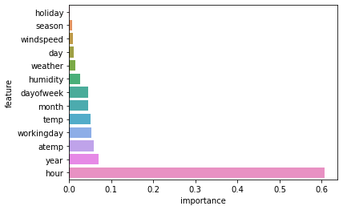

```python
sns.barplot(data=fi_df, x='importance', y='feature')
```